# Blog post: Smart quotes, em dashes, and en dashes

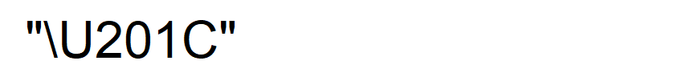

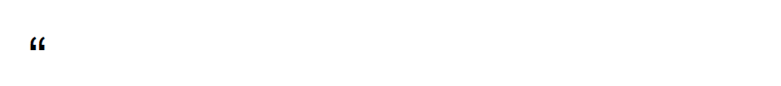

The other smart quote marks are the right double quote,

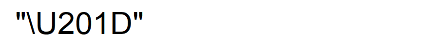

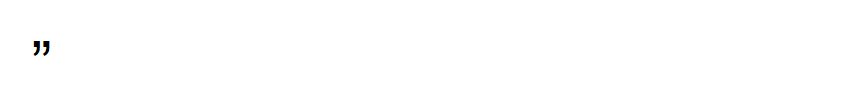

the left single quote,

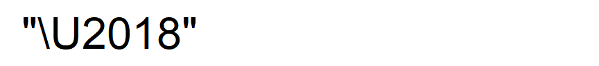

and the right single quote,

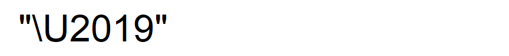

There are a couple of additional codes that I should mention. Most programmers use the minus sign in their coding

but there are two similar characters that you might see. The em dash,

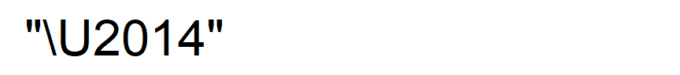

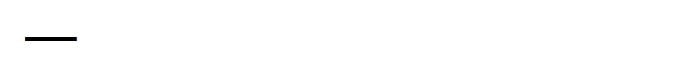

is a longer dash. It has a width equal to the letter “m” in most proportional width fonts. There is another dash, the en dash

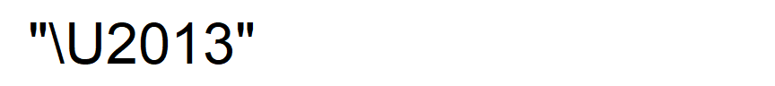

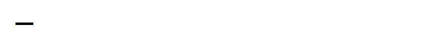

that is also longer than a minus sign, but about half the length of the em dash. It has a width that is equal to the letter “n” in most proportional width fonts.

The em dash and en dash will often cause confusion because they look so much like the minus sign, but they will cause problems often in R code.

There’s a [nice web page](https://www.cl.cam.ac.uk/~mgk25/ucs/quotes.html) about the historical developments of computer codes for quote marks and dashes and [another page](https://cran.r-project.org/web/packages/utf8/vignettes/utf8.html) that talks about computer codes in general from the perspective of an R programmer.

There are some other variants, such as the prime symbols, described in this Wikipedia page.